# Tvyal Newsletter

2024-09-09

*English summary below.*

Հարգելի գործընկեր,

Հուսով եմ՝ լավ եք: Ներկայացնում եմ այս շաբաթվա վերլուծությունները և աշխատանքները.

## [🔌⚡🇦🇲 էլեկտրիկ Հայաստան․ Ցանցի խոցելիությունից մինչև արևային հեռանկարներ](https://www.tvyal.com/newsletter/2024/2024_09_09)

### Հայաստանի էլեկտրականության արտադրության վերլուծություն և կանխատեսում

Վերջին ամիսներին Երևանում նկատվում են էլեկտրականության մատակարարման հաճախակի անջատումներ, հատկապես Կենտրոն և Արաբկիր վարչական շրջաններում։ Այս անջատումները խաթարել են ոչ միայն բնականոն աշխատանքի և երթևեկության ընթացքը, այլ նաև մասսայական միջոցառումներ և կառավարության նիստը։ Այս ամենը նույնիսկ «հովհարային անջատումների» տպավորություն թողեց։ Ըստ Հայաստանի էլեկտրական ցանցերի (ՀԷՑ) այս անջատումները հիմնականում պայմանավորված էին Երևանում շինարարական և ճանապարհային աշխատանքներով։ Ըստ ՀԷՑ ներկայացված տվյալների էլեկտրական մալուխները վնասվել են 31 տոկոս կամ 1569֊ից 492 դեպքում այլ կազմակերպությունների ճանապարհաշինարարական աշխատանքների արդյունքում։ Սակայն ըստ ՀԷՑ-ի տվյալների մնացած 69 տոկոսը վնասվել է հենց ՀԷՑ-ի կողմից:

Գծապատկեր 1.

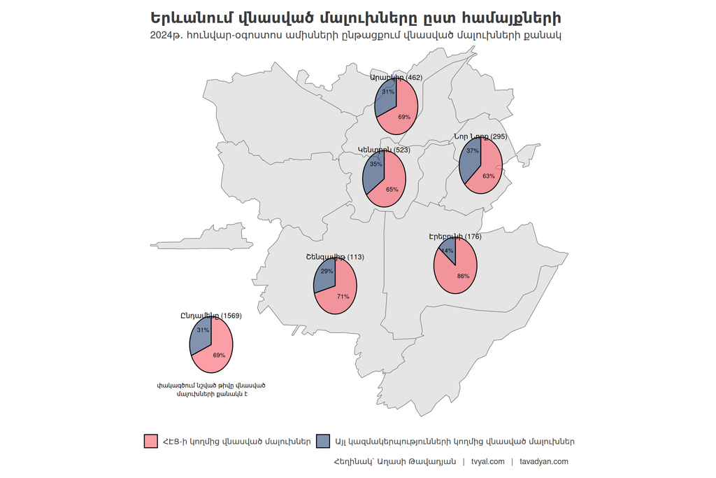

*Այս վերլուծությունը ուսումնասիրում է Հայաստանի էլեկտրական ցանցերի արդի վիճակը, էլեկտրականության արտադրությունը, ինչպես նաև տալիս է 2 տարվա կանխատեսում։ Հիմնական բացահայտումները ներառում են արևային էներգիայի արտադրության զգալի աճը, ինչպես նաև հիդրոէլեկտրակայանների արտադրության նվազումը։*

> 2024թ. հուլիսի դրությամբ արևային էլեկտրակայանները կազմել են էլեկտրաէներգիայի արտադրության **10.1 տոկոսը**:

Գծապատկեր 2.

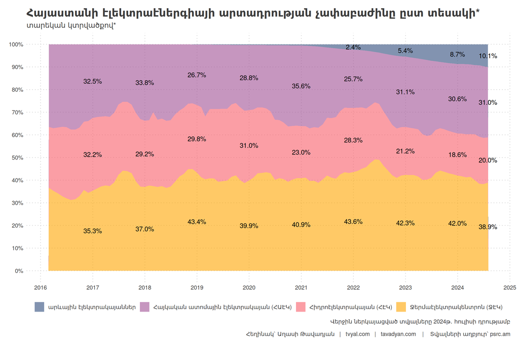

### Արևային էներգիայի կարևորությունը

Ծովային ելք չունեցող Հայաստանի համար, որը մեծապես կախված է ներկրվող հանածո վառելիքից, արևային էներգիան դառնում է առանցքային՝ էներգետիկ անվտանգության ապահովման տեսանկյունից: Նախ արևային էներգիան ապահովում է էներգիայի ապակենտրոնացված աղբյուր՝ նվազեցնելով կախվածությունը արտաքին մատակարարներից և բարելավելով էներգետիկ անվտանգությունը: Նշենք, որ 2023 թվականին 42 տոկոսը կամ 3 715.6 մլն կՎտ ժամը արտադրվել էր ՋԷԿ-ի կողմից, որը օգտագործում է Ռուսաստանից ներմուծված գազ էլեկտրականության արտադրման համար և ներքին շուկայում ամենաթանկ էլեկտրականության աղբյուրն է: Օգտագործելով արևի էներգիան՝ Հայաստանը կարող է զգալիորեն նվազեցնել իր խոցելիությունը աշխարհաքաղաքական լարվածություններից, գների տատանումների և ներմուծվող գազի հետ կապված մատակարարման խափանումներից:

Գծապատկեր 3.

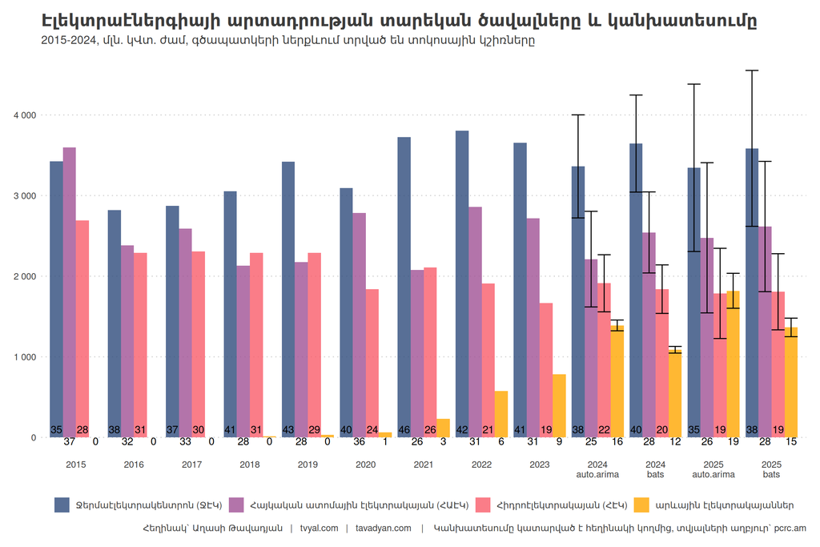

Գծապատկերը արտացոլում է նաև 2024 և 2025 թվականի կանխատեսումները 2 մոդելներով (AUTO.ARIMA և BATS)՝ տալով նաև անորոշության միջակայքը: Ըստ 2 մոդելով կանխատեսման արևային էլեկտրակայանները հզորությունը շարունակում է աճել։ 2024 թվականի վերջին արտադրված էլեկտրականության 12-16 տոկոսը տրամադրելու են արևային էլեկտրակայանները։ Հնրավար է որ 2025 թվականի վերջին արևային էլեկտրակայանների էլեկտրաէներգիայր արդտադրությունը գերազանցի հիդրոէլեկտրոկայանների արտադրությունը։ Այսպես ըստ կանխատեսումներից մեկի 2025 թվականին արևային էլեկտրաէներգիան կազմելու է ամբողջ արտադրության 19 տոկոսը։

### Աճի հետ կապված մարտահրավերներ

Նշենք որ այս աճը որոշակի խնդիրներ կարող է բերել, այսպես արևային էլեկտրաէներգիայի արտադրությունը ունի օրական և տարեկան սեզոնայնությունը։ Պիկային արտադրության ժամը կեսօրին է, սակայն պիկային սպառման ժամը՝ երեկոյան, երբ արևը արդեն մայր է մտնում։ Ավել աճի պարագայում պետք է լուծել հավելյալ արտադրված էլեկտրականության մարտկոցային պահպանման կամ այլ միջազգային ցանցերին միանալու հարցը, որպեսզի էլեկտրաէներգիայի արտադրությունը և սպառումը բալանսավորված լինեն։

Գծապատկեր 4.

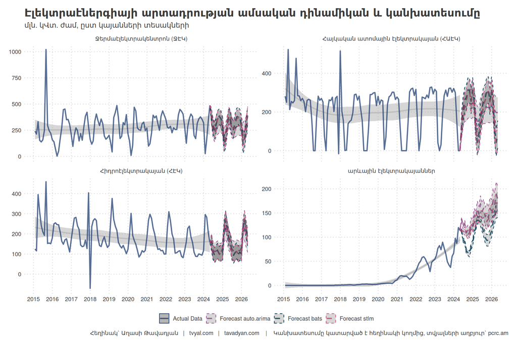

4-րդ գծապատկերում ցուցադրված է Հայաստանում արտադրված էլեկտրաէներգիայի ամսական ծավալները` ըստ էլեկտրակայանների տեսակների: Գծապատկերում տրված է նաև 2 տարվա կանխատեսումը մինչև 2026 թվականի հունիսը:

> Ձեզ կարող է հետաքրքրել նաև հետևյալ վերլուծությունները.
> - [💎🎭🔮️ Ոսկե Պատրանք. Հայաստանի արտահանման իրական պատկերը](https://www.tvyal.com/newsletter/2024/2024_09_02)։
> - [🆘🇦🇲🧑🏼‍💻 SOS ՀՀ ՏՏ․ ռազմավարական առաջնահերթությունից մինչև հնարավոր անկում](https://www.tvyal.com/newsletter/2024/2024_08_19)։
> - [👛💨💰 Դատարկ գրպաններ, բարձր աշխատավարձր](https://www.tvyal.com/newsletter/2024/2024_08_12)։
> - [🧮⏳🎲 Հայաստանը հարկում է ժամանակը․ Խաղ տնտեսական աճի հետ](https://www.tvyal.com/newsletter/2024/2024_08_02)։

Գծապատկեր 5.

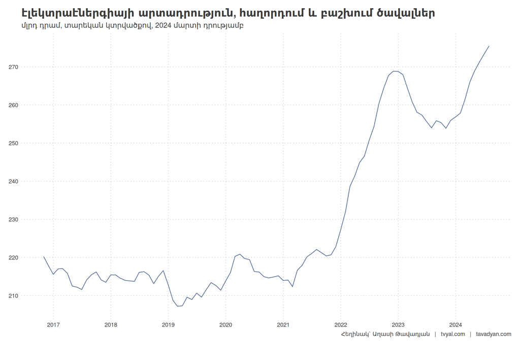

Վերջին գծապատկերը արտացոլում է արդյունաբերական արտադրանքի արտադրության ծավալներնի մեջ էլեկտաէներգիայի արտադրությունը ընթացիկ գներով։ Գծապատկերը տրված է տարեկան կտրվածքով։ Այստեղ, ինչպես նաև մեր այլ վերլուծություններում, երևում է էլեկտրականության արտադրության սրընթաց աճը 2022 թվականին։ Ընդհանուր էլեկտրականության արտադրության ծավալը դրամով աճել է 18.3% 2022 թվականին (227.2 մլրդ դրամից մինչև 268.8 մլրդ դրամ), որը արտացուլում էր տնտեսության աճը Ռուսատանից զգալի կապիտալ ներհոսքին համահունչ և շինարարության զգալի աճը։ 2023 թվականին արդեն գրանցվել է 4.4% անկում՝ մինչև 256.9 մլրդ դրամ, որը նույնպես ցույց է տալիս որ 2022 թվականի զգալի աճը ուներ ժամանակավոր միտում։ 2024 թվականից արդեն առկա է էլեկտէներգիայի արտադրության աճ։

### Եզրակացություն

Աշխարհում առկա է էլեկտրական մեքենաներին և ջեռուցման վերականգնողական միջոցներին անցնելու միտում։ Բնակարանների տաքացման ու մեքենաների լիցքավորման զգալի մասը հնարավոր է, որ ապագայում կատարվելու է էլեկտրականությամբ: Վերջինս կբարձրացնի էլեկտրականության հանդեպ պահանջարկը և այս պարագայում տնային տնտեսությունների սպառման աճը կավելացնի էլեկտրաէներգիայի արտադրությունը։ Սակայն, սա կարող է սթրեսի ենթարկել Հայաստանի էներգետիկ համակարգը, քանի որ, եթե տնային տնտեսությունների մեծամասնությունը անցում կատարեն էլեկտրական մեքենաներին և էլեկտրականությամբ ջեռուցման, ապա սա կարող է կմեծացնել էլեկտրաէներգիայի պահանջարկը մոտ 2 անգամ, որի ենթակառուցվածքային հնարավորությունները այս պահին Հայաստանը չունի: Պահանջարկի և առաջարկի հնարավոր կրկնապատկումը կարող է լարվածության տակ դնել էլեկտրական ենթակառուցվածքները, որոնք անհրաժեշտ է հրատապ թարմացնել: Այս ռիսկերից խուսափելու համար անհրաժեշտ է մեծացնել արտադրական հզորությունները և էլեկտրաֆիկացման ենթակառուցվածքների քանակությունը: Այսպես, պետք է որոշակի պլան ներդրված լինի, որ մի քանի տարում Հայաստանի էլեկտրական ենթակառուցվածքները պատրաստ լինեն ապահովել տարեկան 18 000 մլն կՎտ ժամ հոսանք:

* 2023 թվականից առկա է արևային էլեկտրականության արտադրության հաշվարկային փոփոխություն։ Արևային էլեկտրաէներգիայի արտադրության ծավալներում ներառված են նաև էլեկտրաէներգիայի փոխհոսքերի մասով ինքնավար արտադրողների կողմից արտադրված էլեկտրաէներգիայի քանակությունները։ Սա հաշվի առնելու համար մինչև 2023 թվականի արևային էլեկտրականության արտադրության ցուցանիշները ճշգրտվել են։

Եթե հնարավոր է, խնդրում եմ այս նյութը ուղարկել նաև այն մարդկանց, ում այն կարծում եք կարող է հետաքրքրել:

**ԱՅՍ ՀՈԴՎԱԾԻ ՀՂՈՒՄԸ**

*Թավադյան, Աղ․Ա․ (2024)․ էլեկտրիկ Հայաստան․ Ցանցի խոցելիությունից մինչև արևային հեռանկարներ [Electric Armenia: From Grid Vulnerability to Solar Prospects]․ Tvyal.com հարթակ [Tvyal.com platform], 09-09-2024․ https://www.tvyal.com/newsletter/2024/2024_09_09*

**Արգելվում է այս հարթակի նյութերը արտատպել առանց հղում կատարելու։**

* Այս և մեր բոլոր այլ վերլուծությունների տվյալները վերցված են պաշտոնական աղբյուրներից։ Հաշվարկները ամբողջությամբ հասանելի են github-ում, դրանք կարելի է ստուգել` այցելելով [github-ի](https://github.com/tavad/tvyal_newsletter/blob/main/2024/) մեր էջը, որտեղ տրված են տվյալները, հաշվարկների և գծապատկերների կոդը։

# ՀԱՄԱԳՈՐԾԱԿՑՈՒԹՅՈՒՆ

## Եթե ուզում եք AI գործիքներով ձեր տվյալներից օգուտ քաղել` ԴԻՄԵՔ ՄԵԶ

### Մենք առաջարկում ենք

- Extensive databases for finding both international and local leads
- Exclusive reports on the Future of the Armenian Economy
- Work and browser automation to streamline operations and reduce staffing needs
- AI models for forecasting growth and optimizing various aspects of your business
- Advanced dashboarding and BI solutions
- Algorithmic trading

### Let’s Put Your Data to Work!

### ՄԻԱՑԵՔ ՄԵՐ ԹԻՄԻՆ

## ԶԼՄ հաղորդագրություն

[Դիտեք 1in.am լրատվամիջոցին տված իմ վերջին հարցազրույցը, եթե ուզում եք իմանալ տնտեսության իրական վիճակի մասին](https://youtu.be/WMymScFP0hc&t=565s)

📺 Ծուղակի մեջ ենք. դրամի արժեզրկումը կմեծացնի պետական պարտքը. Աղասի Թավադյան 📺

[figure not shown]

Նաև կարդացեք նոր հոդվածը JAM News-ում՝ Հայաստանի ՏՏ ոլորտի իրավիճակի մասին, որը պարունակում է նաև իմ մեկանաբանությունը։ Աշխատողները պակասել են, խոշոր հարկատուները՝ ավելացել․ իրավիճակը Հայաստանի ՏՏ ոլորտում

## English Summary

### 🔌⚡🇦🇲 Electric Armenia: From Grid Vulnerability to Solar Prospects

This analysis examines the current state of Armenia’s electrical grid, electricity production, and provides a two-year forecast. The report highlights recent frequent power outages in Yerevan, particularly in the Central and Arabkir administrative districts, which have disrupted normal work, traffic, and even government sessions. While the Armenian Electric Networks attribute these outages mainly to construction and road works, data shows that 69% of cable damages were caused by the company itself. The analysis reveals a significant increase in solar energy production, which accounted for 10.1% of electricity generation as of July 2024, while noting a decline in hydroelectric power production.

The report emphasizes the importance of solar energy for Armenia, a landlocked country heavily dependent on imported fossil fuels. Solar power is seen as a crucial factor in improving energy security and reducing vulnerability to geopolitical tensions and supply disruptions. Forecasts suggest that by the end of 2024, solar power plants could provide 12-16% of the country’s electricity, potentially surpassing hydroelectric production by the end of 2025. However, the analysis also points out challenges associated with this growth, such as the need for energy storage solutions to balance production and consumption. The report concludes by discussing the potential impact of increased electrification in heating and transportation on Armenia’s energy system, highlighting the need for significant infrastructure upgrades to meet future demand.

Այս վերլուծությունը առկա է նաև [մեր կայքէջում](https://www.tvyal.com/newsletter/2024/2024_09_09), այս վերլուծության կոդը և տվյալները դրված են նաև [Github-ում](https://github.com/tavad/tvyal_newsletter)։

Եթե հնարավոր է, խնդրում եմ այս նյութը ուղարկել նաև այն մարդկանց, ում այն կարծում եք կարող է հետաքրքրել:

Սպասեք հաջորդ հաղորդագրությանը հաջորդ ուրբաթ օրը:

Հարգանքներով,  
Աղասի Թավադյան  
09.09.2024  
[tvyal.com](https://www.tvyal.com/)  
[tavadyan.com](https://www.tavadyan.com/)

[Was this email forwarded to you? Subscribe here.](https://www.tvyal.com/subscribe)

[Բաժանորդագրվեք](https://www.tvyal.com/subscribe)